# Model lasu losowego na danych ankietowych

Bartosz Dąbrowski

3 05 2020

# Wczytanie danych

Pierwszym etapem jest import i podgląd danych do analizy.

```r
head(data,10)
```

```
## # A tibble: 10 x 29
##    `Sygnatura czasowa` `Płeć:` `Ile masz lat?` `Z jakiego woje~
##    <dttm>              <chr>   <chr>           <chr>
##  1 2020-04-01 19:55:14 Mężczy~ 22              małopolskie
##  2 2020-04-01 21:00:58 Kobieta 22              podkarpackie
##  3 2020-04-01 22:06:14 Mężczy~ 21              małopolskie
##  4 2020-04-02 18:29:51 Mężczy~ 22              małopolskie
##  5 2020-04-02 18:35:03 Kobieta 22              śląskie
##  6 2020-04-02 18:35:13 Kobieta 21              lubelskie
##  7 2020-04-02 18:35:44 Kobieta 22              małopolskie
##  8 2020-04-02 18:35:47 Mężczy~ 21              śląskie
##  9 2020-04-02 18:36:16 Mężczy~ 23              podkarpackie
## 10 2020-04-02 18:37:54 Kobieta 21              małopolskie
## # ... with 25 more variables: `Jaka jest wielkość Twojego miejsca
## #   zamieszkania?` <chr>, `W jakim mieście studiujesz?` <chr>, `Czy
## #   studiujesz na więcej niż jednym kierunku?` <chr>, `Na którym roku
## #   aktualnie jesteś?` <chr>, `Na jakiej uczelni studiujesz?` <chr>, `W
## #   jakim trybie studiujesz?` <chr>, `Jaki jest typ Twojej
## #   uczelni?` <chr>, `Jaka dziedzina nauk najlepiej określa Twoje
## #   studia?` <chr>, `Czy należysz do kół naukowych?` <chr>, `Czy należysz
## #   do organizacji studenckich?` <chr>, `Czy należysz do
## #   samorządu?` <chr>, `Ile wynosi Twoja średnia ocen z całych
## #   studiów?` <chr>, `Czy udało Ci się w trakcie studiów uzyskać
## #   stypendium naukowe?` <chr>, `Gdzie mieszkałeś/mieszkałaś w trakcie
## #   studiów?` <chr>, `Jak oceniasz jakość nauczenia przedmiotów wiodących
## #   na Twoim kierunku?` <dbl>, `Jak oceniasz jakość nauczania przedmiotów
## #   niezwiązanych z kierunkiem (tzw. "zapychaczy")?` <dbl>, `Jak oceniasz
## #   dobór przedmiotów niezwiązanych z kierunkiem?` <dbl>, `Jak oceniasz
## #   jakość nauczania języka obcego?` <dbl>, `Jak oceniasz szeroko pojętą
## #   organizację na uczelni (dziekanat, kontakt z prowadzącymi, dział
## #   kształcenia, itp.)?` <dbl>, `Jak oceniasz swoje plany zajęć pod
## #   względem wygody grafiku?` <dbl>, `Jak oceniasz "trudność" swoich
## #   studiów?` <dbl>, `Jak oceniasz przydatność swoich studiów i wiedzy z
## #   nich wyniesionej w pracy?` <dbl>, `Jak ogólnie oceniasz swoje
## #   studia?` <dbl>, `Kiedy zacząłeś/zaczęłaś pracę w branży
## #   docelowej?` <chr>, `To już wszystko z mojej strony. Czy
## #   chiałbyś/chciałabyś coś dodać?` <chr>
```

# Oczyszczanie danych

Zmiana kolumn w formacie **str** na **factor**.

```r
data<-as.data.frame(data)
data[,4]<-parse_factor(data[,4],levels=unique(sort(data[,4])))
data[,5]<-parse_factor(data[,5],levels=c("poniżej 5 tysięcy","5 - 20 tysięcy","20 - 100 tysięcy", "100 - 200 tysięcy","200 - 500 tysięcy","powyżej 500 tysięcy"))
data[,8]<-parse_factor(data[,8],levels=c('I','II','III','IV','V','Ukończyłem/ukończyłam studia'))
data[,11]<-parse_factor(data[,11],levels=c("Artystyczna","Ekonomiczna","Pedagogiczna","Techniczna","Uniwersytet","Inna"))
data[,12]<-parse_factor(data[,12],levels=c("Architektura","Automatyka/elektrotechnika","Biologia","Chemia","Dziennikarstwo/komunikacja społeczna","Ekonometria","Ekonomia/finanse","Farmacja","Filologia","Fizyka/astronomia","Geografia","Historia","Informatyka/telekomunikacja","Inżynieria biomedyczna","Inżynieria chemiczna","Inżynieria lądowa/budownictwo/transport","Inżynieria materiałowa","Inżynieria mechaniczna","Inżynieria środowiska/energetyka/górnictwo","Kulturoznawstwo/religioznawstwo","Matematyka","Medycyna","Nauki o bezpieczeństwie","Pedagogika","Prawo/administracja","Psychologia","Socjologia","Sztuki piękne","Technologia żywności","Weterynaria/zootechnika","Zarządzanie","Inne"))
data[,16]<-parse_factor(data[,16],levels=unique(sort(data[,16])))
data[,28]<-parse_factor(data[,28],levels=c("Jeszcze nie pracuję","Przed początkiem studiów","I rok","II rok", "III rok","IV rok","V rok", "Później"))
```

Oczyszczanie odpowiedzi - ujednolicenie odpowiedzi bez polskich znaków, z literówkami, dodatkowymi komentarzamim, a także połączenie tych miast, w przypadku których nie ma różnicy w dostępie do pracy, uczelni czy w średnich cenach, i które w praktyce można niemal traktować jak jedno miasto - Trójmiasto oraz Górnośląski Okręg Przemysłowy.

Przed:

```
##
##           Białystok           BIAŁYSTOK           Bydgoszcz
##                   3                   1                   5
##               Bytom              Deblin              Gdansk
##                   1                   1                   2
##              Gdańsk              Gdynia             Gliwice
##                  25                   2                   2
## Gorzów Wielkopolski            Katowice              Kielce
##                   1                  18                   3
##              Krakow               Krakó              Kraków
##                   2                   1                 124
##           Kraków xD                 krk              Leszno
##                   1                   3                   1
##              Lublin                Łódź           Nowy Sącz
##                  17                  18                   2
##           Nowy Targ             Olsztyn               Opole
##                   1                   1                   3
##            Oświęcim              Poznan              poznań
##                   1                   1                   1
##              Poznań             Rzeszów              słupsk
##                  32                   4                   1
##               Sopot           Sosnowiec            Szczecin
##                   1                   2                   8
##               Toruń       Toruń, Poznań  Uniwersytet Śląski
##                  10                   1                   1
##            Warszasa            Warszawa                Wawa
##                   1                  68                   1
##             Wrocław              Zabrze        Zielona Góra
##                  38                   1                   3
```

Po:

```
##
##           Białystok           Bydgoszcz              Dęblin
##                   4                   5                   1
## Gorzów Wielkopolski            Katowice              Kielce
##                   1                  25                   3
##              Kraków              Leszno              Lublin
##                 131                   1                  17
##                Łódź           Nowy Sącz           Nowy Targ
##                  18                   2                   1
##             Olsztyn               Opole            Oświęcim
##                   1                   3                   1
##              Poznań             Rzeszów              Słupsk
##                  34                   4                   1
##            Szczecin               Toruń          Trójmiasto
##                   8                  11                  30
##            Warszawa             Wrocław        Zielona Góra
##                  70                  38                   3
```

W przypadku kolumn z 2 możliwymi odpowiedziami, można je zamienić na zmienne zero-jedynkowe.

```r
data[,2]<-if_else(data[,2]=="Kobieta",1,0)
data[,9]<-if_else(data[,9]=="Prywatna",1,0)
data[,10]<-if_else(data[,10]=="Zaocznie",1,0)
data[,7]<-if_else(data[,7]=="Tak",1,0)
data[,13:15]<-if_else(data[,13:15]=="Tak",1,0)
data[,17]<-if_else(data[,17]=="Tak",1,0)
```

Odpowiedzi do pytania o lokum wyeksportowane zostały w formie tekstowej, z zaznaczonymi opcjami wymienionymi po przecinku. Aby je wyodrębnić do osobnych kolumn, zastosowano kombinację **if_else** i **str_detect** z pakietu *stringr*.

```r
data<-data%>%
  mutate(Akademik=if_else(str_detect(data[,18],coll("Akademik")),1,0),
         Dom_mieszkanie_rodzinne=if_else(str_detect(data[,18],coll("Dom/mieszkanie rodzinne")),1,0),
         Wynajete_mieszkanie=if_else(str_detect(data[,18],coll("Wynajęte mieszkanie")),1,0),
         Wynajety_pokoj=if_else(str_detect(data[,18],coll("Wynajęty pokój")),1,0),
         Inne=if_else(str_detect(data[,18],coll("Inne")),1,0))
```

Tworząc ankietę, użyty został aktualny podział na dziedziny ustalonego przez Ministerstwo Szkolnictwa Wyższego. Zmienna o 32 możliwych wartościach ma jednak niską wartość predykcyjną i zwiększa ryzyko wykrycia fałszywych korelacji (zwłaszcza w przypadku kierunków z niską liczbą respondentów). W tym celu zostaną one zastąpione przypisaniem do dyscyplin, które, choć niedokładne, pozwalają na większe uogólnienie i generalizację.

Przed:

```
##  [1] "Architektura"
##  [2] "Automatyka/elektrotechnika"
##  [3] "Biologia"
##  [4] "Chemia"
##  [5] "Dziennikarstwo/komunikacja społeczna"
##  [6] "Ekonometria"
##  [7] "Ekonomia/finanse"
##  [8] "Farmacja"
##  [9] "Filologia"
## [10] "Fizyka/astronomia"
## [11] "Geografia"
## [12] "Historia"
## [13] "Informatyka/telekomunikacja"
## [14] "Inżynieria biomedyczna"
## [15] "Inżynieria chemiczna"
```

[output cut: 17 more lines]

```r
data<-data%>%
  mutate(Dyscyplina = ifelse(data[,12] %in% c('Biologia','Chemia', 'Geografia'),'Nauki przyrodnicze',ifelse(data[,12]  %in% c('Psychologia','Socjologia','Zarządzanie','Nauki o bezpieczeństwie','Pedagogika','Ekonomia/finanse','Ekonometria','Prawo/administracja','Dziennikarstwo/komunikacja społeczna'),'Nauki spoleczne',ifelse(data[,12]  %in% c('Inżynieria biomedyczna','Inżynieria chemiczna','Inżynieria materiałowa','Inżynieria mechaniczna','Inżynieria środowiska/energetyka/górnictwo','Inżynieria lądowa/budownictwo/transport',"Architektura","Automatyka/elektrotechnika"),'Nauki inzynieryjno-techniczne',ifelse(data[,12]  %in% c('Historia','Kulturoznawstwo/religioznawstwo',"Filologia"),'Nauki humanistyczne',ifelse(data[,12]  %in% c('Medycyna','Farmacja'),'Nauki o zdrowiu',ifelse(data[,12]  %in% c('Fizyka/astronomia','Informatyka/telekomunikacja',"Matematyka"),'Nauki scisle',ifelse(data[,12]  %in% c("Technologia żywności","Weterynaria/zootechnika" ),'Nauki rolnicze',levels(data[,12])[`Jaka dziedzina nauk najlepiej określa Twoje studia?`]))))))))
data[,35]<-parse_factor(data[,35],levels=unique(sort(data[,35])))
data<-data[,-12]
```

Po:

```
## [1] "Inne"                          "Nauki humanistyczne"
## [3] "Nauki inzynieryjno-techniczne" "Nauki o zdrowiu"
## [5] "Nauki przyrodnicze"            "Nauki rolnicze"
## [7] "Nauki scisle"                  "Nauki spoleczne"
## [9] "Sztuki piękne"
```

Ostatnim elementem jest uproszczenie outputu - opcja niepracująca to ponad 60% odpowiedzi, podczas gdy II stopień i “później” łącznie to niespełna 5%. Aby to wyrównać, zastosowano generalizację wszystkich opcji “pracujących” i połączenie w jedną, o reprezentacji w danych wynoszącej blisko 40%. **1** oznacza osoby pracujące, **0** - nie.

Przed:

```
##
##      Jeszcze nie pracuję Przed początkiem studiów                    I rok
##                      258                       30                       25
##                   II rok                  III rok                   IV rok
##                       45                       34                       12
##                    V rok                  Później
##                        4                        5
```

Po:

```
##
##   0   1
## 258 155
```

Na potrzeby modelu, usunąć należy kolumny bez zdolności predykcyjnej - sygnaturę czasową, dobrowolny feedback oraz pytanie o miejsce zamieszkanie w trakcie studiów, które zostało już rozbite na 5 zmiennych zero-jedynkowych.

Dla większej czytelności zmieniono nazwy kolumn.

```
##  [1] "Kobieta"                 "Wiek"
##  [3] "Wojewodztwo_pochodzenia" "Wielkosc_miasta"
##  [5] "Miasto"                  "Wiecej_kierunkow"
##  [7] "Rok"                     "Prywatna"
##  [9] "Zaocznie"                "Typ"
## [11] "Kola"                    "Organizacje"
## [13] "Samorzad"                "Srednia"
## [15] "Stypendium"              "Wiodace"
## [17] "Zapychacze"              "Zapychacze_dobor"
## [19] "Jezyk"                   "Organizacja_uczelni"
## [21] "Plany"                   "Trudnosc"
## [23] "Przydatnosc"             "Ogolna_ocena"
## [25] "Praca"                   "Akademik"
## [27] "Dom_mieszkanie_rodzinne" "Wynajete_mieszkanie"
## [29] "Wynajety_pokoj"          "Inne"
## [31] "Dyscyplina"
```

# MODELE

```
##
## Call:
##  randomForest(formula = Praca ~ ., data = df, ntree = 1000, mtry = 5,      importance = TRUE)
##                Type of random forest: classification
##                      Number of trees: 1000
## No. of variables tried at each split: 5
##
##         OOB estimate of  error rate: 27.36%
## Confusion matrix:
##     0  1 class.error
## 0 215 43   0.1666667
## 1  70 85   0.4516129
```

```
##                                   0            1 MeanDecreaseAccuracy
## Kobieta                  0.51724976  0.412572537            0.6312368
## Wiek                    16.36617914  8.650387622           18.0235881
## Wojewodztwo_pochodzenia  7.64319803 -1.357040575            5.5420606
## Wielkosc_miasta          2.92966807 -0.447567108            2.1341537
## Miasto                   8.19117443 -3.818412675            4.5110445
## Wiecej_kierunkow        -0.11877651 -0.558435424           -0.3964521
## Rok                     12.74642746  8.535444027           15.6760072
## Prywatna                 1.16934767 -3.109188984           -0.9879237
## Zaocznie                13.04384368 10.584473476           15.6422660
## Typ                     -0.03119119 -0.865486830           -0.5255859
## Kola                    -1.12132327 -0.657003263           -1.3708291
## Organizacje             -1.40591421  1.108119493           -0.5563733
## Samorzad                 0.03936417 -1.640851378           -0.9223615
## Srednia                  0.50486302  0.001521247            0.3187521
## Stypendium               6.61825007  3.815963570            7.5290253
## Wiodace                  0.73884386  0.423253754            0.8871304
## Zapychacze               0.56867667  0.289691333            0.6100328
## Zapychacze_dobor         1.36920174  1.888077247            2.1946993
## Jezyk                    2.00247268  1.093516306            2.1929210
## Organizacja_uczelni     -0.46454152  0.793142940            0.1859097
## Plany                    0.48164363  0.632319413            0.8401345
## Trudnosc                 9.06931806  3.178017583            8.6928385
## Przydatnosc              0.64431790  1.656992046            1.5314582
## Ogolna_ocena             0.89533920 -0.704394653            0.2142046
## Akademik                 4.17688501 -0.867018537            2.7790173
## Dom_mieszkanie_rodzinne -0.52930919 -2.192445274           -1.8464197
## Wynajete_mieszkanie     -1.14204145 -1.760813105           -2.0660753
## Wynajety_pokoj           1.50328117 -0.642367315            0.8110672
## Inne                     0.16321511 -2.052204436           -1.3892455
## Dyscyplina              13.48245902 18.084690146           20.8135561
##                         MeanDecreaseGini
## Kobieta                        2.6002878
## Wiek                          14.0566469
## Wojewodztwo_pochodzenia       20.8719667
## Wielkosc_miasta                9.8197071
## Miasto                        17.5640315
## Wiecej_kierunkow               0.7264669
## Rok                           14.3982856
## Prywatna                       0.7620159
## Zaocznie                       5.0879924
## Typ                            5.3475021
## Kola                           2.0841762
## Organizacje                    1.4520701
## Samorzad                       1.6035288
## Srednia                        6.0794623
## Stypendium                     3.6877234
## Wiodace                        5.1480866
## Zapychacze                     5.6769731
## Zapychacze_dobor               6.5740706
## Jezyk                          6.6759289
## Organizacja_uczelni            6.2655177
## Plany                          6.7142737
## Trudnosc                       7.9604098
## Przydatnosc                    5.9290650
## Ogolna_ocena                   5.2334210
## Akademik                       2.0668191
## Dom_mieszkanie_rodzinne        2.1962003
## Wynajete_mieszkanie            2.4259789
## Wynajety_pokoj                 2.4892588
## Inne                           0.4582046
## Dyscyplina                    20.3466155
```

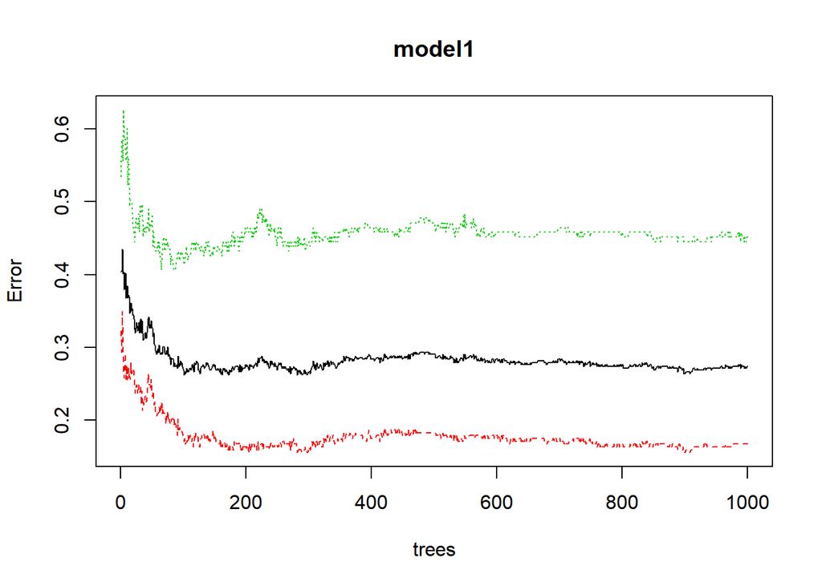

```
## AUC:  0.6908602
## OOB Error:  0.2736077
## Accuracy:  0.7263923
## Sensitivity:  0.8333333
## Specifity:  0.5483871
## G-Mean:  0.6760098
## Recall:  0.754386
## Precision:  0.8333333
```

Pierwszy zbudowany model cechuje stosunkowa dobra dokładność - 72,5%. Ma dość wysoką czułość kosztem niskiej swoistości - wiąże się to z dużo lepszym wykrywaniem bezrobotnych, podczas gdy skuteczność w przypadku pracujących wynosi niewiele ponad 50%. Najprawdopodobniej wpływ na to ma dysproporcja w próbkach. W następnym modelu zostaną one wyrównane.

## Model z wyrównanymi próbkami

```
##
## Call:
##  randomForest(formula = Praca ~ ., data = df, ntree = 1000, mtry = 5,      importance = TRUE, sampsize = c(155, 155))
##                Type of random forest: classification
##                      Number of trees: 1000
## No. of variables tried at each split: 5
##
##         OOB estimate of  error rate: 31.23%
## Confusion matrix:
##     0   1 class.error
## 0 179  79   0.3062016
## 1  50 105   0.3225806
```

```
##                                  0           1 MeanDecreaseAccuracy
## Kobieta                  2.2289738 -0.57585425           1.57116107
## Wiek                    13.9620772 11.52499599          18.02318664
## Wojewodztwo_pochodzenia  8.4449982 -1.36528452           6.70830673
## Wielkosc_miasta          1.1215513  0.82599473           1.42559287
## Miasto                   7.4931952 -3.40007662           4.81886425
## Wiecej_kierunkow         0.6063825  0.79797385           0.87328045
## Rok                     11.4957988 10.06773242          15.79183156
## Prywatna                -0.6908766 -1.74835607          -1.54439208
## Zaocznie                11.1948584 10.72446530          14.51191808
## Typ                      0.8344397 -1.96416776          -0.28674350
## Kola                    -2.6484392  1.14036298          -1.77766506
## Organizacje             -1.1921762  0.93260810          -0.41417534
## Samorzad                -0.1900640 -2.12513004          -1.37535448
## Srednia                 -1.5312242 -0.95508125          -1.93636897
## Stypendium               3.9115302  4.37341165           5.72980646
## Wiodace                 -0.4364521  0.34819746          -0.12878731
## Zapychacze              -3.3451810  0.61846008          -2.64799481
## Zapychacze_dobor        -2.0277435  1.16646298          -1.23839566
## Jezyk                    1.0050212  0.76252634           1.24749690
## Organizacja_uczelni     -1.9663684  2.66245282          -0.06665164
## Plany                    1.5812762  1.84611139           2.37106460
## Trudnosc                 6.8938537  3.30965127           7.49930293
## Przydatnosc              0.6331635  2.38125680           1.86186814
## Ogolna_ocena             0.1628234 -0.08826668           0.14217813
## Akademik                 4.2717698 -1.97098324           2.66691742
## Dom_mieszkanie_rodzinne -0.7573169 -1.20193770          -1.32080707
## Wynajete_mieszkanie     -0.3978618 -0.40249065          -0.50481435
## Wynajety_pokoj           3.4024211 -1.59868084           2.13016141
## Inne                    -0.7939412 -2.18771476          -1.96176217
## Dyscyplina              10.3533361 17.11433731          17.38731712
##                         MeanDecreaseGini
## Kobieta                        2.0951187
## Wiek                          10.9135751
## Wojewodztwo_pochodzenia       17.1696491
## Wielkosc_miasta                8.3477314
## Miasto                        15.1388149
## Wiecej_kierunkow               0.5555660
## Rok                           11.3102648
## Prywatna                       0.5897513
## Zaocznie                       3.3204539
## Typ                            4.2293289
## Kola                           1.6759276
## Organizacje                    1.1761319
## Samorzad                       1.2352606
## Srednia                        5.0010367
## Stypendium                     3.0032491
## Wiodace                        4.1620811
## Zapychacze                     4.4899047
## Zapychacze_dobor               5.3129258
## Jezyk                          5.2222980
## Organizacja_uczelni            5.1634256
## Plany                          5.3363612
## Trudnosc                       5.9214152
## Przydatnosc                    4.7525904
## Ogolna_ocena                   4.1769318
## Akademik                       1.6361809
## Dom_mieszkanie_rodzinne        2.0108044
## Wynajete_mieszkanie            1.8920613
## Wynajety_pokoj                 2.0258679
## Inne                           0.4556311
## Dyscyplina                    16.0189117
```

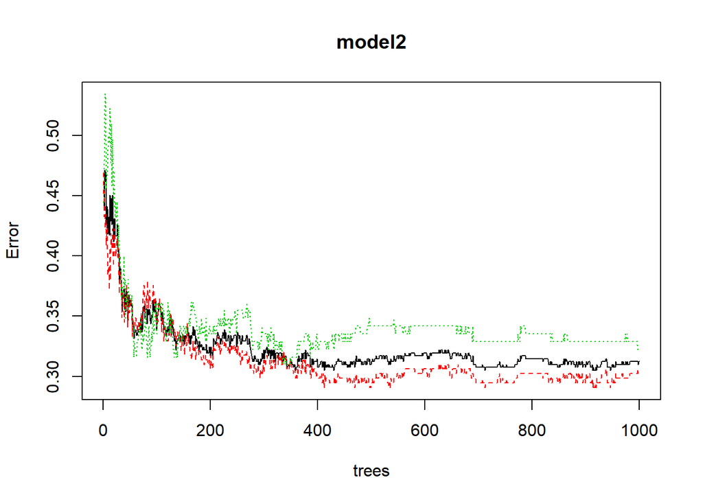

```
## AUC:  0.6856089
## OOB Error:  0.3123487
## Accuracy:  0.6876513
## Sensitivity:  0.6937984
## Specifity:  0.6774194
## G-Mean:  0.68556
## Recall:  0.7816594
## Precision:  0.6937984
```

Ogólna skuteczność, jak i AUC uległo pogorszeniu. W zamian za to, wyrównaniu uległy czułość i swoistość, i model radzi sobie z klasyfikacją obu grup w podobnym stopniu. Pomimo nieco gorszych wyników, ma on większą wartość.

## PODZIAŁ NA DANE TESTOWE I TRENINGOWE

Przyjmuję wstępnie podział 70% dla danych uczących i 30% dla testowych.

```
##
##   0   1
## 177 112
```

```
##
## Call:
##  randomForest(formula = Praca ~ ., data = df_train, ntree = 1000,      mtry = 5, importance = TRUE, sampsize = c(100, 100))
##                Type of random forest: classification
##                      Number of trees: 1000
## No. of variables tried at each split: 5
##
##         OOB estimate of  error rate: 36.68%
## Confusion matrix:
##     0  1 class.error
## 0 111 66   0.3728814
## 1  40 72   0.3571429
```

```
##                                  0           1 MeanDecreaseAccuracy
## Kobieta                 -1.4720590 -1.45485022           -2.1314954
## Wiek                    10.8806878  9.65332045           13.8128921
## Wojewodztwo_pochodzenia  2.6518054 -2.87681865            0.6879398
## Wielkosc_miasta          0.6411001 -0.63411606            0.1521145
## Miasto                   6.1144405  1.20936871            5.9115741
## Wiecej_kierunkow         1.6525072  0.39354892            1.4236395
## Rok                      6.9064625  1.90573889            7.1896475
## Prywatna                 0.4940234 -2.78427764           -1.4039410
## Zaocznie                12.3617203 10.26663914           14.7017391
## Typ                     -0.9641219 -1.55910316           -1.6998765
## Kola                    -2.2659219  0.50133817           -1.6136623
## Organizacje              0.7528244  1.81033168            1.4432517
## Samorzad                -1.6012900 -1.85273621           -2.2326045
## Srednia                 -1.6477450 -1.82960890           -2.5037454
## Stypendium               2.6660838  5.19101704            5.2208146
## Wiodace                 -2.4549258  2.13655189           -1.1557979
## Zapychacze              -3.9018283  0.01349811           -3.3025416
## Zapychacze_dobor        -1.5463367  4.06801702            0.8849366
## Jezyk                   -1.4251099 -0.45871737           -1.4721681
## Organizacja_uczelni     -3.1939855  2.14004938           -1.3437388
## Plany                   -1.1696788 -2.13094628           -2.2249571
## Trudnosc                 3.5579009  1.42545475            3.7254847
## Przydatnosc             -0.8742117  0.91607588           -0.1319352
## Ogolna_ocena            -2.6905063 -1.22630335           -3.2289589
## Akademik                 4.5957992 -0.46628158            3.7234174
## Dom_mieszkanie_rodzinne -0.7903242 -0.73584876           -1.1637600
## Wynajete_mieszkanie     -1.3240145 -0.38321079           -1.3973133
## Wynajety_pokoj           0.4308934 -2.56040649           -1.0699601
## Inne                    -1.6184504 -1.74289729           -2.4548150
## Dyscyplina               4.6872945  9.41400403            9.0992526
##                         MeanDecreaseGini
## Kobieta                        1.2703763
## Wiek                           6.7957525
## Wojewodztwo_pochodzenia       12.0362550
## Wielkosc_miasta                5.3973096
## Miasto                        10.9952033
## Wiecej_kierunkow               0.3944279
## Rok                            6.1319273
## Prywatna                       0.4385823
## Zaocznie                       2.2949861
## Typ                            2.7888206
## Kola                           1.0665510
## Organizacje                    0.8518516
## Samorzad                       0.7582548
## Srednia                        3.1816719
## Stypendium                     2.0380782
## Wiodace                        2.8553047
## Zapychacze                     2.9091121
## Zapychacze_dobor               3.7110546
## Jezyk                          3.3399464
## Organizacja_uczelni            3.3608680
## Plany                          3.3386119
## Trudnosc                       3.8318680
## Przydatnosc                    2.8958556
## Ogolna_ocena                   2.4282641
## Akademik                       1.0731459
## Dom_mieszkanie_rodzinne        1.1634185
## Wynajete_mieszkanie            1.4499993
## Wynajety_pokoj                 1.2417185
## Inne                           0.2389831
## Dyscyplina                     9.2226499
```

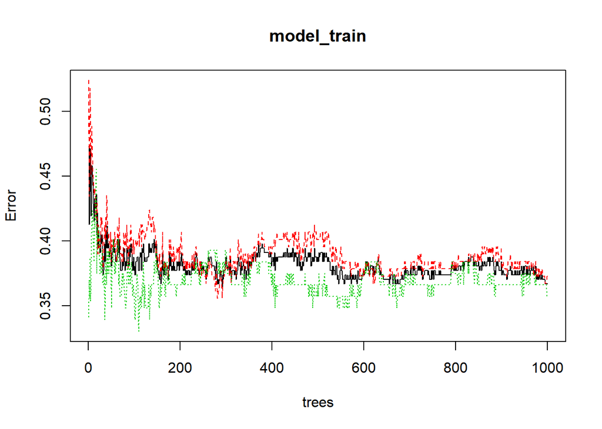

```
## AUC:  0.717772
## OOB Error:  0.2903226
## Accuracy:  0.7096774
## Sensitivity:  0.8358209
## Specifity:  0.5614035
## G-Mean:  0.6850057
## Recall:  0.691358
## Precision:  0.8358209
```

Sytuacja w tym momencie wydaje się dość zastanawiająca. Wyniki na zbiorze testowym prezentują się lepiej, niż na treningowym - jest niższy błąd, AUC wygląda lepiej, niż w poprzednich modelach. Nie do końca wiem, gdzie (i czy) robię błąd.

## Próba wykluczenia z modelu obserwacji o wątpliwej wiarygodności

Niektórzy z respondentów w pytaniu o feedback zgłaszali problemy z ankietą - najczęściej były to wątpliwości co do przypisania swojej uczelni bądź kierunku, niekiedy niepewność co do właściwego interpretowania swojej pracy - czy jest ona związana ze studiami. Do następnego modelu wykorzystane zostaną dane oczyszczone z takich obserwacji.

```
##
##   0   1
## 250 150
```

```
##
## Call:
##  randomForest(formula = Praca ~ ., data = df2, ntree = 1000, mtry = 5,      importance = TRUE, sampsize = c(150, 150))
##                Type of random forest: classification
##                      Number of trees: 1000
## No. of variables tried at each split: 5
##
##         OOB estimate of  error rate: 29.75%
## Confusion matrix:
##     0   1 class.error
## 0 180  70   0.2800000
## 1  49 101   0.3266667
```

```
##                                    0          1 MeanDecreaseAccuracy
## Wiek                    14.472183668 12.9144616           19.4027157
## Wojewodztwo_pochodzenia  5.759850863  0.2987165            5.1066478
## Wielkosc_miasta          1.488774021  0.4018970            1.4806356
## Miasto                   6.900506403  0.6311141            6.5657391
## Wiecej_kierunkow         0.001150632 -1.0990390           -0.6343814
## Rok                     10.388167318  9.4274772           14.7991067
## Prywatna                 0.055011972 -2.4895885           -1.3072639
## Zaocznie                11.349863573 11.7850554           14.5604025
## Typ                     -0.360341018 -1.5713294           -1.1592440
## Kola                    -3.508707650 -0.9454037           -3.5949047
## Organizacje             -4.759979087  1.9406631           -2.6984178
## Samorzad                -0.910392136 -1.8207866           -1.7176208
## Srednia                 -0.175671679  0.6251079            0.1917388
## Stypendium               3.405069994  4.0559996            5.1344197
## Wiodace                 -2.461879678 -0.9545284           -2.6780177
## Zapychacze_dobor        -4.038913135  4.6558171           -1.0459633
## Jezyk                   -0.467927751 -0.5728537           -0.7080538
## Organizacja_uczelni     -2.217165225  2.2469680           -0.7289708
## Plany                   -2.904453786  4.1766505           -0.2618895
## Trudnosc                 7.133547872  3.1340292            7.4364806
## Przydatnosc             -1.179202421  0.6811654           -0.6860714
## Ogolna_ocena             0.823738446  1.1880963            1.3134642
## Akademik                 4.810316298  0.6397408            4.4738122
## Dom_mieszkanie_rodzinne -0.952058820 -1.7624749           -1.7830869
## Wynajety_pokoj          -0.843075663 -1.3357156           -1.4083430
## Inne                     0.539458487 -2.0450918           -0.6729873
## Dyscyplina              11.558324504 19.9098070           19.5687597
##                         MeanDecreaseGini
## Wiek                          11.2965199
## Wojewodztwo_pochodzenia       17.4532383
## Wielkosc_miasta                8.2495929
## Miasto                        15.7311951
## Wiecej_kierunkow               0.5506264
## Rok                           11.5067937
## Prywatna                       0.7132916
## Zaocznie                       3.5255666
## Typ                            4.1070014
## Kola                           1.8614932
## Organizacje                    1.2321937
## Samorzad                       1.2944271
## Srednia                        5.0876651
## Stypendium                     3.1163958
## Wiodace                        4.2100503
## Zapychacze_dobor               5.4653896
## Jezyk                          5.2250848
## Organizacja_uczelni            5.1850781
## Plany                          5.5785756
## Trudnosc                       5.9962665
## Przydatnosc                    4.8574597
## Ogolna_ocena                   4.2837039
## Akademik                       1.5690977
## Dom_mieszkanie_rodzinne        2.0135382
## Wynajety_pokoj                 1.9126051
## Inne                           0.4532861
## Dyscyplina                    16.8575763
```

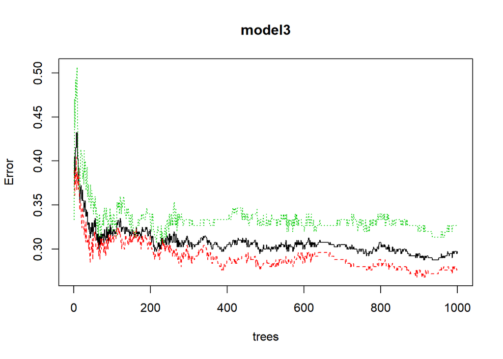

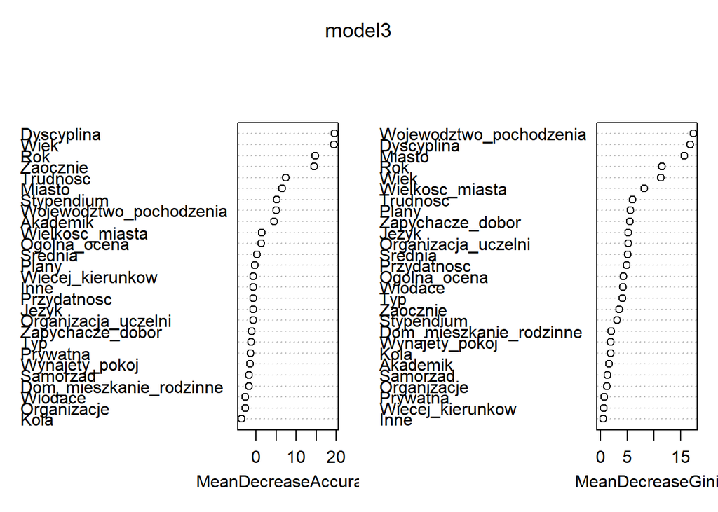

```
## AUC:  0.6966667
## OOB Error:  0.2975
## Accuracy:  0.7025
## Sensitivity:  0.72
## Specifity:  0.6733333
## G-Mean:  0.6962758
## Recall:  0.7860262
## Precision:  0.72
```

Z 13 usuniętych przypadków, 8 było błędni klasyfikowanych - 5 pracujących było uznawanych za bezrobotnych, 3 bezrobotnych - za pracujących. Przyniosło to delikatną poprawę; jest to najlepszy z dotychczasowych modeli na pełnych danych.

### Model oczyszczony z wątpliwych obserwacji z podziałem na dane treningowe i testowe

Podobnie jak wcześniej, przyjmuję podział 0,7:0,3.

```
##
##   0   1
## 177 103
```

```
##
## Call:
##  randomForest(formula = Praca ~ ., data = df_train2, ntree = 1000,      mtry = 5, importance = TRUE, sampsize = c(100, 100))
##                Type of random forest: classification
##                      Number of trees: 1000
## No. of variables tried at each split: 5
##
##         OOB estimate of  error rate: 35.36%
## Confusion matrix:
##     0  1 class.error
## 0 114 63   0.3559322
## 1  36 67   0.3495146
```

```
##                                  0          1 MeanDecreaseAccuracy
## Wiek                    11.8640028 11.9197455          16.44333998
## Wojewodztwo_pochodzenia  7.0951622  1.0103022           6.71680235
## Wielkosc_miasta          2.5260582  1.3149780           2.73683029
## Miasto                   3.8314255 -3.1749781           1.64392884
## Wiecej_kierunkow         3.2503751  3.2845789           4.28060608
## Rok                      6.5337908 11.4845780          11.89460435
## Prywatna                -0.3116776  0.5043694          -0.02125627
## Zaocznie                 9.6602215 11.5886854          13.29321381
## Typ                     -1.7594637 -0.2578590          -1.67736807
## Kola                     2.0734110  2.4995830           3.09358053
## Organizacje             -1.1704515 -0.1293290          -1.12371534
## Samorzad                 1.7140756 -1.9494421           0.27784764
## Srednia                 -0.4302469  1.3321092           0.26822679
## Stypendium               5.0064929  3.6641768           6.04134628
## Wiodace                 -1.5593259  2.9797560           0.27283562
## Zapychacze_dobor        -0.9706479 -0.9728287          -1.31953757
## Jezyk                    0.2293750  0.2079606           0.30186718
## Organizacja_uczelni     -1.9656076  1.1028358          -1.13532904
## Plany                   -1.3764158  1.3637972          -0.41261250
## Trudnosc                 3.6858321  4.0384171           5.15750199
## Przydatnosc              0.2817511 -0.7137927          -0.10222384
## Ogolna_ocena            -2.3291460 -1.7396829          -2.99304746
## Akademik                 3.7195919 -1.4507803           2.36238727
## Dom_mieszkanie_rodzinne -1.3301460 -2.0980697          -2.30198114
## Wynajety_pokoj           2.2592015 -2.2753127           0.75000512
## Inne                     1.0765888  1.5536376           1.67571985
## Dyscyplina               8.1049730 11.1187033          12.32774853
##                         MeanDecreaseGini
## Wiek                           7.2973036
## Wojewodztwo_pochodzenia       13.6349677
## Wielkosc_miasta                6.1443011
## Miasto                         9.9505774
## Wiecej_kierunkow               0.4060716
## Rok                            7.7640168
## Prywatna                       0.4984798
## Zaocznie                       2.5176143
## Typ                            2.5577262
## Kola                           1.3968332
## Organizacje                    0.6784088
## Samorzad                       0.7029315
## Srednia                        3.4126534
## Stypendium                     2.1091258
## Wiodace                        2.6520601
## Zapychacze_dobor               3.5829310
## Jezyk                          3.3424929
## Organizacja_uczelni            3.1881612
## Plany                          3.4979119
## Trudnosc                       3.8812475
## Przydatnosc                    2.9401903
## Ogolna_ocena                   2.5248350
## Akademik                       1.1525997
## Dom_mieszkanie_rodzinne        1.1999821
## Wynajety_pokoj                 1.2761620
## Inne                           0.4224769
## Dyscyplina                    10.8998517
```

```
## [1] 0.6472766
```

```
## AUC:  0.679831
## OOB Error:  0.325
## Accuracy:  0.675
## Sensitivity:  0.7741935
## Specifity:  0.5689655
## G-Mean:  0.6636938
## Recall:  0.6575342
## Precision:  0.7741935
```

Po raz kolejny skuteczność na danych testowych jest wyższa, niż na treningowych. Być może spowodowane jest to mniejszą liczbą danych.